# Medidas de tendencia central

[Alondra Garcia Jacobo](https://alondragarciaj.github.io)

Taller IV 2022-2, [Facultad de economía](http://www.economia.unam.mx/)

2/3/2022

### 1. ¿Qué son las medidas de tendencia central?

> “La **medida de tendencia central** (moda,media y mediana), **parámetro de tendencia central** o **medida de centralización** es un número ubicado hacia el centro de la distribución de los valores de una serie de observaciones (medidas), en la que se encuentra ubicado el conjunto de los datos. Las medidas de tendencia central más utilizadas son: media, mediana u moda. Cuando se hace referencia únicamente a la posición de estos parámetros dentro de la distribución, independientemente de que esté más o menos centrada, se habla de estas medidas como **medidas de posición**.”

[Wikipedia (2022)](https://es.wikipedia.org/wiki/Medidas_de_tendencia_central)

Para este ejemplo, primero generaremos una serie de **100** números aleatorios entre **1** y **20** mediante la función `sample`. El argumento `TRUE` nos permitirá generar una muestra con remplazo:

```r
numeros <- sample(1:20, 100, TRUE)
numeros
```

```
##   [1] 14  7  9 16  5  8 12 19  6 18  5  8  5  8  2  5 13 20 19 15 11  5  2 18 10
##  [26] 13  1  2  5 15 12  9  4 20  8  2  7  6 12  4 19 16  3 18 14 19 17  7 13  8
##  [51] 12 11 13 16  7  3  6 20  9 13 11  5 12 16 11 17  4 13 14 20  9 10  1  1 12
##  [76]  9  6 11  1 18 10  9  5 13 10 16 10 10  8 15  7  5 13  9 18 12  5  2  3  2
```

### 2. Mediana

“La **mediana** es un **estadístico** de posición central que parte la distribución en dos, es decir, deja la misma cantidad de valores a un lado que a otro. Las fórmulas propuestas no nos darán el valor de la mediana, lo que nos darán será la posición en la que está dentro del conjunto de datos.”

[Economipedia (2022)](https://economipedia.com/definiciones/medidas-de-tendencia-central.html)

Para obtener la **mediana**, podemos ordenar los `numeros` de menor a mayor, **el número que esté en medio de la muestra será la mediana**. Si utilizamos R, se puede hacer el cálculo de la **mediana** con la función `median`:

```r
mediana <- median(numeros)
mediana
```

```
## [1] 10
```

### 3. Media

“La **media** es el valor promedio de un conjunto de datos numéricos, calculada como la suma del conjunto de valores dividida entre el número total de valores.”

[Economipedia 2022](https://economipedia.com/definiciones/medidas-de-tendencia-central.html)

$$Media ={\frac {1}{n}}\sum _{i=1}^{n}a_{i}={\frac {a_{1}+a_{2}+\cdots +a_{n}}{n}}$$

Si usamos R, podemos obtener la media de una muestra si utlilizamos la función **mean**:

```r
media <- mean(numeros)
media
```

```
## [1] 10.07
```

### 4. Moda 📊

“La moda es el el valor que más se repite en una muestra estadística o población. No tiene fórmula en sí mismo. Lo que habría que realizar es la suma de las repeticiones de cada valor.

[Economipedia(2022)](https://economipedia.com/definiciones/medidas-de-tendencia-central.html)

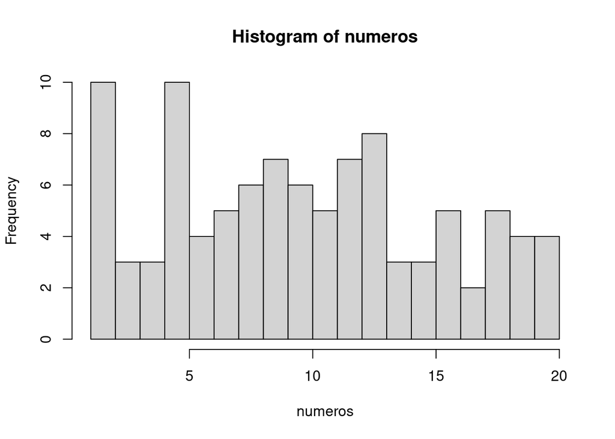

```r
# El argumento breaks nos permite dividir en histograma en las partes que queramos
hist(numeros, breaks = 20)
```

Para obtener un resultado con más precisión, podemos obtener la **moda** si generamos una **tabla de frecuencias** con la función `table` y la función `data.frame`, **aquel elemento con mayor frecuencia será la moda**:

```r
tabla.frecuencias <- data.frame(table(numeros))
tabla.frecuencias
```

```
##    numeros Freq
## 1        1    4
## 2        2    6
## 3        3    3
## 4        4    3
## 5        5   10
## 6        6    4
## 7        7    5
## 8        8    6
## 9        9    7
## 10      10    6
## 11      11    5
## 12      12    7
## 13      13    8
## 14      14    3
## 15      15    3
## 16      16    5
## 17      17    2
## 18      18    5
## 19      19    4
## 20      20    4
```

### 5. Ejercicio 👩‍💻👨‍💻✍

Aplica lo que aprendiste, obten la **mediana**, **media** y **moda** de la siguiente muestra de números:

```r
# Con la función seq, creamos una secuencia de 1 a 10 en intervalos de 0.1 en 0.1
secuencia <- seq(1, 10, 0.1)
muestra <- sample(secuencia, 100, TRUE)
muestra
```

```
##   [1]  5.9  3.1  2.4  3.4  1.4  7.8  6.3  2.4  5.1  9.4  1.9  3.1  6.1  3.2  8.2
##  [16]  3.6  8.2  9.9  4.8  7.2  3.7  7.3  6.2  4.8  7.5  8.1  6.5  7.9  6.1  3.5
##  [31]  5.0  3.5  4.8  9.8  8.4  3.6  4.8  6.3  5.4  2.6  9.6  1.9  1.3  8.9  6.6
##  [46]  4.2  1.9  4.0  6.9  6.6  1.8  2.8  9.8  4.2  5.3  6.8  3.0  3.1  2.0  4.3
##  [61]  4.3  2.6  4.6  8.8  5.2  8.8  4.4  1.5  4.4  8.8  5.1  8.8  9.9  7.4  1.7
##  [76]  2.9 10.0  7.6  4.4  6.3  7.5  3.2  4.1  9.4  1.2  5.2  3.4  4.3  9.5  4.1
##  [91]  3.8  7.5  6.4  9.5  3.9  1.3  2.5  9.9  7.1  1.6
```

##### Mediana

```r
# Aquí el cálculo de la mediana
mediana.muestra <- median(muestra)
mediana.muestra
```

```
## [1] 4.9
```

##### Media

```r
# Aquí el cálculo de la media
mediana.muestra <- mean(muestra)
mediana.muestra
```

```
## [1] 5.371
```

##### Moda

```r
# Aquí el cálculo de la moda
tabla.moda <- data.frame(table(muestra))
tabla.moda
```

```
##    muestra Freq
## 1      1.2    1
## 2      1.3    2
## 3      1.4    1
## 4      1.5    1
## 5      1.6    1
## 6      1.7    1
## 7      1.8    1
## 8      1.9    3
## 9        2    1
## 10     2.4    2
## 11     2.5    1
## 12     2.6    2
## 13     2.8    1
## 14     2.9    1
```

[output cut: 49 more lines]

💻[Código disponible en RStudio Cloud](https://rstudio.cloud/project/3671022)💻